# Dissolved Oxygen Recovery Project

Difference (winkler - electrode measurement per sample ID) was plotted over DO concentration for each cruise, blue line are at y = 0 and red lines represent simple linear regression of the data.

For HUD2011004

```r
wd <- list()
for (i in 1:length(H11004_wink_data)){
  if (is.null(H11004_wink_elec_1[[i]])){
    wd[[i]] <- NULL
  } else{
    wd[[i]] <- H11004_wink_data[[i]]
  }
}
length(H11004_wink_elec_1) <- length(wd)
plot(unlist(wd), unlist(H11004_wink_elec_1), ylim = c(-3,3), xlab = 'DO Concentrations, ml/l', ylab = 'Difference (Winkler - electrode)')
abline(h = 0, col = 'blue')
```

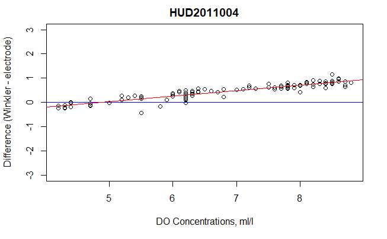

```r
lh <- lm(unlist(H11004_wink_elec_1) ~ unlist(wd))
abline(lh, col = 'red')
title(main = 'HUD2011004')
```

```r
summary(lh)
```

```
Call:
lm(formula = unlist(H11004_wink_elec_1) ~ unlist(wd))

Residuals:
     Min       1Q   Median       3Q      Max
-0.57249 -0.07691  0.01129  0.09296  0.32293

Coefficients:
             Estimate Std. Error t value Pr(>|t|)
(Intercept) -1.109656   0.067524  -16.43   <2e-16 ***
unlist(wd)   0.228027   0.009637   23.66   <2e-16 ***
---
Signif. codes:  0 ‘***’ 0.001 ‘**’ 0.01 ‘*’ 0.05 ‘.’ 0.1 ‘ ’ 1

Residual standard error: 0.1319 on 102 degrees of freedom
  (27 observations deleted due to missingness)
Multiple R-squared:  0.8459,    Adjusted R-squared:  0.8444
F-statistic: 559.9 on 1 and 102 DF,  p-value: < 2.2e-16
```

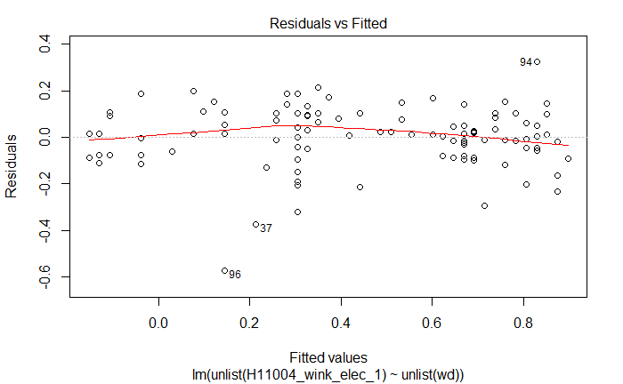

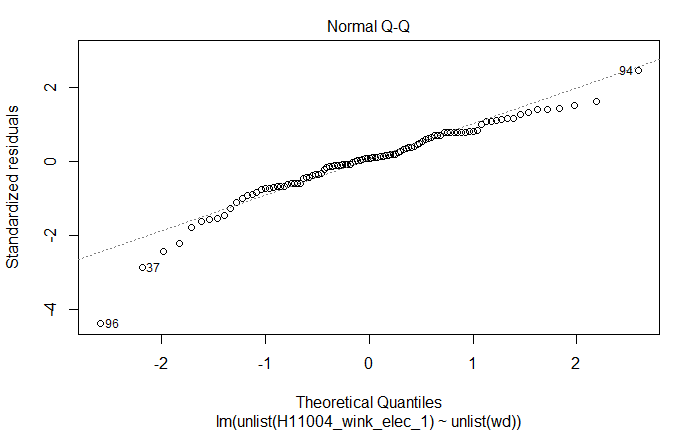

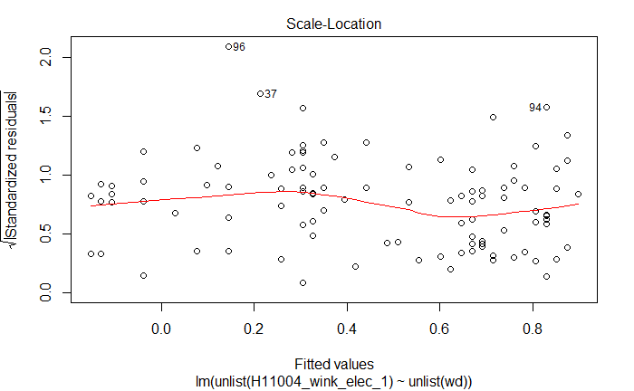

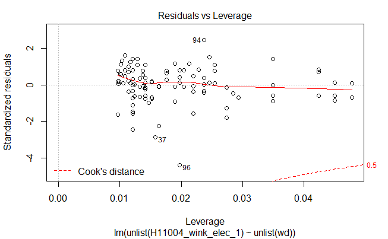

```r
plot(lh)
```

For HUD2011043

```r
wd2 <- list()
for (i in 1:length(H11043_wink_elec_1)){
  if (is.null(H11043_wink_elec_1[[i]])){
    wd2[[i]] <- NULL
  } else{
    wd2[[i]] <- H11043_wink_data[[i]]
  }
}
wd2 <- unlist(wd2)
length(wd2) <- 56
plot(wd2, unlist(H11043_wink_elec_1), ylim = c(-3,3), xlab = 'DO Concentrations, ml/l', ylab = 'Difference (Winkler - electrode)')
abline(h = 0, col = 'blue')
```

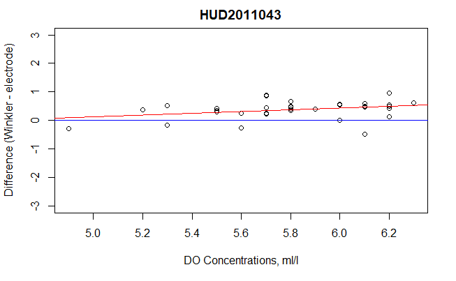

```r
lh2 <- lm(unlist(H11043_wink_elec_1) ~ wd2)
abline(lh2, col = 'red')
title(main = 'HUD2011043')
```

```r
summary(lh2)
```

```
Call:
lm(formula = unlist(H11043_wink_elec_1) ~ wd2)

Residuals:
     Min       1Q   Median       3Q      Max
-0.95656 -0.06824  0.02838  0.13253  0.53755

Coefficients:
            Estimate Std. Error t value Pr(>|t|)
(Intercept)  -1.4374     0.9250  -1.554   0.1301
wd2           0.3115     0.1589   1.961   0.0587 .
---
Signif. codes:  0 ‘***’ 0.001 ‘**’ 0.01 ‘*’ 0.05 ‘.’ 0.1 ‘ ’ 1

Residual standard error: 0.3055 on 32 degrees of freedom
  (22 observations deleted due to missingness)
Multiple R-squared:  0.1072,    Adjusted R-squared:  0.07933
F-statistic: 3.844 on 1 and 32 DF,  p-value: 0.05869
```

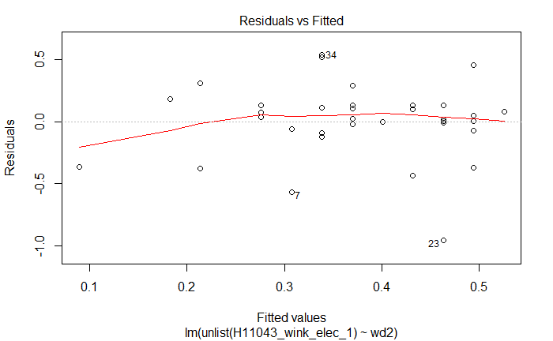

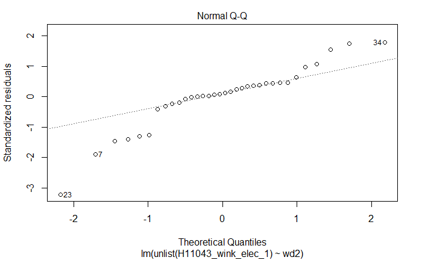

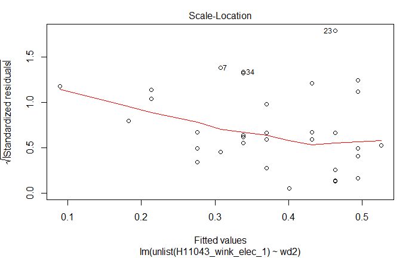

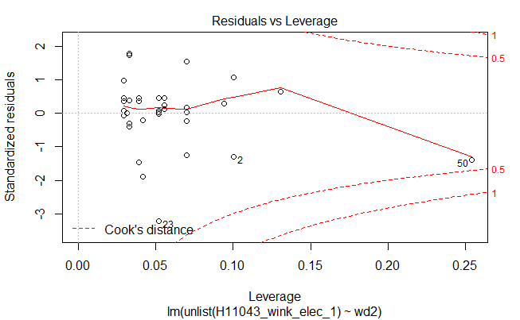

```r
plot(lh2)
```

For HUD2012042

```r
wd3 <- list()
for (i in 1:length(H12042_wink_elec_1)){
  if (is.null(H12042_wink_elec_1[[i]])){
    wd3[[i]] <- NULL
    }
  else{
    wd3[[i]] <- H12042_wink_data[[i]]
  }
}
plot(unlist(wd3), unlist(H12042_wink_elec_1), ylim = c(-3,3), xlab = 'DO Concentrations, ml/l', ylab = 'Difference (Winkler - electrode)')
abline(h = 0, col = 'blue')
```

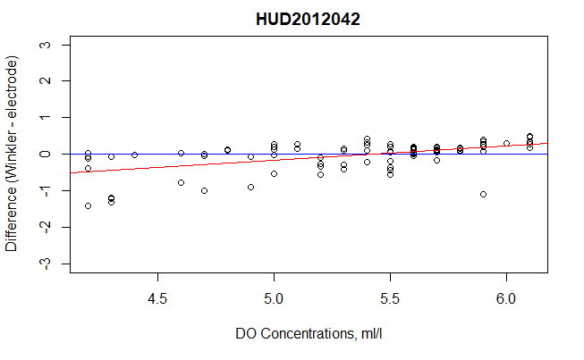

```r
lh3 <- lm(unlist(H12042_wink_elec_1) ~ unlist(wd3))
abline(lh3, col = 'red')
title(main = 'HUD2012042')
```

```r
summary(lh3)
```

```
Call:
lm(formula = unlist(H12042_wink_elec_1) ~ unlist(wd3))

Residuals:
     Min       1Q   Median       3Q      Max
-1.29387 -0.08654  0.05764  0.21150  0.52617

Coefficients:
            Estimate Std. Error t value Pr(>|t|)
(Intercept) -2.17202    0.33825  -6.421 5.83e-09 ***
unlist(wd3)  0.40032    0.06292   6.362 7.63e-09 ***
---
Signif. codes:  0 ‘***’ 0.001 ‘**’ 0.01 ‘*’ 0.05 ‘.’ 0.1 ‘ ’ 1

Residual standard error: 0.3385 on 92 degrees of freedom
  (72 observations deleted due to missingness)
Multiple R-squared:  0.3055,    Adjusted R-squared:  0.298
F-statistic: 40.48 on 1 and 92 DF,  p-value: 7.628e-09
```

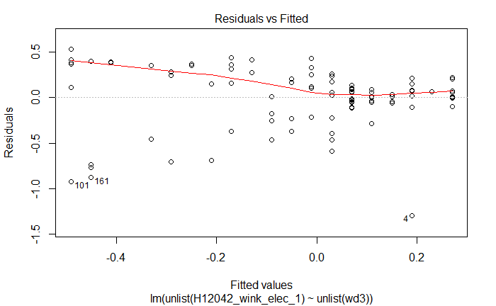

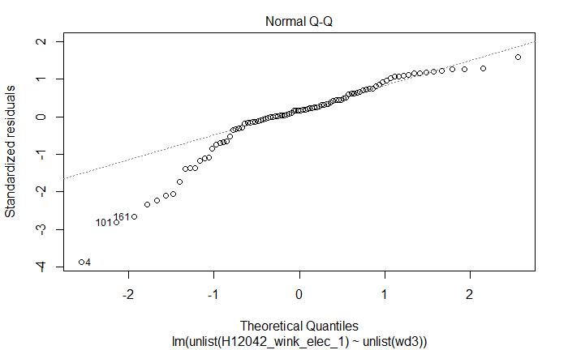

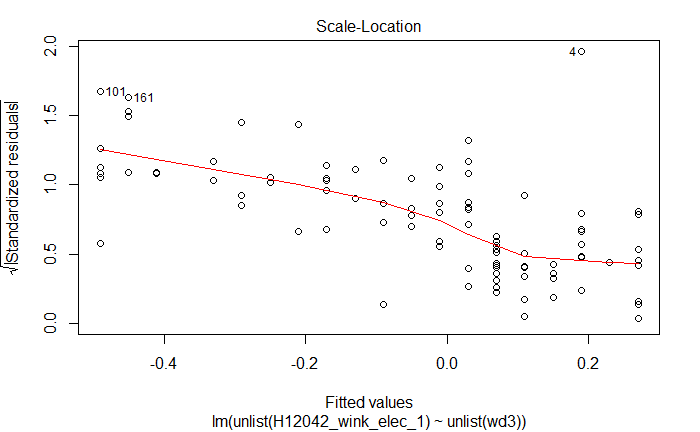

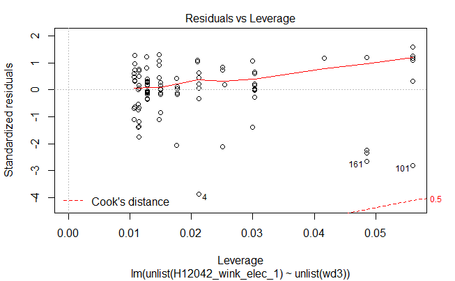

```r
plot(lh3)
```

These plots show some interesting trends of accuracy over DO concentrations.

The trend seems to be a slightly increased under estimation by the electrode at higher DO concentrations. Keeping in mind the small range of DO concentrations that are visible in this data this may be a significant trend.

Groundfish surveys were also analyzed in order to bulk up the data set. A total of 55 new data points were discovered where winkler and lectrode measurments were performed for the same sample ID.

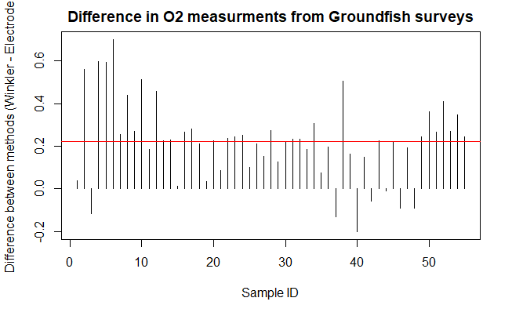

```r
#read in groundfish data
data <- readxl::read_xlsx('C:/Users/ChisholmE/Desktop/BIOCHEM/GROUNDFISH OXYGEN DATA.xlsx' )
#isolate by cruise
NED2013022 <- (5:935)
NED2014018 <- (937:1669)
NED2015017 <- (1674:2161) #CAUTIOUS OF DUPLICATE VALUE, x__4 IS ELECTRODE VALUE AVERAGED BETWEEN REPS
#read data column containing difference (Winkler- electrode)
DIFF <- as.numeric(as.character(data$X__6[-1]))
diff <- na.omit(DIFF)
#plot differences over both cruises due to minimal data points
plot(diff, type = 'h', xlab = 'Sample ID', ylab = 'Difference between methods (Winkler - Electrode)', main = 'Difference in O2 measurments from Groundfish surveys')
m <- mean(diff)
abline(h = m, col = 'red')
```

Plotting these difference over dissolved oxygen concetrations revealed trends consistent with AZMP data

```r
#isolate concentrations from Winkler measurments for relevant sample IDs
conc <- list()
for ( i in 1:2648){
  if(is.na(data$X__6[-1][i]) ){
    conc[i] <- NA
  }else{
    conc[i] <- as.numeric(data$X__5[-1][i])
  }
}

c <- na.omit(unlist(conc))
#conc <- data$X__5[!is.na(DIFF) ]
#plot differences over concentration
plot(conc, DIFF, xlab = 'Dissolved Oxygen Concentration (ml/L)', ylab = 'Difference between measurements (Winkler - electrode)')
abline(h = 0, col = 'blue')
```

```r
#linear regression
cm <- lm(unlist(DIFF) ~unlist(conc))
abline(cm, col = 'red')
#plot potential correction factors
#of 2, 4, 6 %
twoperc <- list()
for (i in 1:length(conc)){
  twoperc[i] <- as.numeric(conc[i]) *0.02
}
pm <- lm(unlist(twoperc)~unlist(conc))
abline(pm, col = 'green')
```

```r
fourperc <- list()
for (i in 1:length(conc)){
  fourperc[i] <- as.numeric(conc[i]) *0.04
}
fm <- lm(unlist(fourperc)~unlist(conc))
abline(fm, col = 'orange')
sixperc <- list()
for (i in 1:length(conc)){
  sixperc[i] <- as.numeric(conc[i]) *0.06
}
sm <- lm(unlist(sixperc)~unlist(conc))
abline(sm, col = 'purple')
```

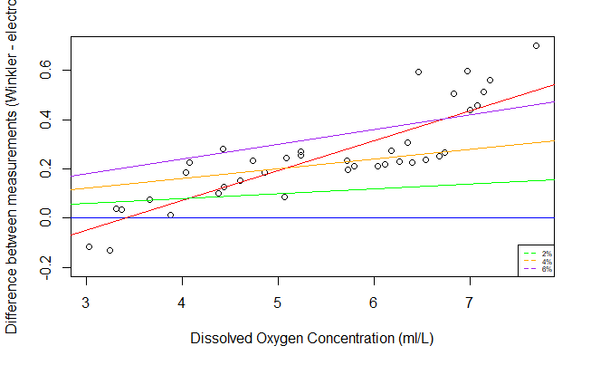

```r
legend('bottomright', legend = c('2%', '4%', '6%'), col = c('green', 'orange', 'purple'), lty = 2, cex = 0.5 )
```

Potential correction factors of 2, 4,6 % of dissolved oxygen concentrations were also plotted. Through visual inspection it appears the 4% correction factors agrees best with the data although there is still signifcant unexplained variability particularly at higher DO concentration values which may indicate a non linear trend.

Regression was performed over groundfish surveys and AZMP cruies to find a common trend in the total data set.

```r
#plot original data
plot(wt, et, xlim = c(0, 10), ylim = c(0,10), col = 'red', xlab = 'Winkler (ml/L)', ylab = 'Electrode (ml/L)')
#regression of original data
ttlm <- lm(wt ~as.numeric(et))
abline(ttlm, col = 'red', lty = 2)
```

```r
#plot 1:1 line reference
abline(coef = c(0,1), col = 'blue')
#apply correction factor following ttlm regression equation
eet <- list()
for (i in 1:length(et)){
  eet[i] <- as.numeric(et[i])*1.1424 - 0.6171
}
#plot corrected data for comparision
par(new = TRUE)
```

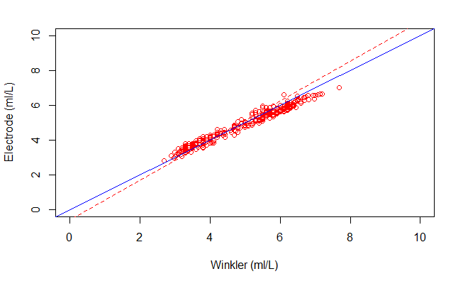

```r
plot(wt, eet, xlim = c(0,10), ylim = c(0,10), xlab = '', ylab = '', axes = FALSE, col = 'blue')
mtext(side = 3, 'Original data (red), Corrected data (blue)')
```

```r
#regress corrected data to ensure high correlation and 1.00 slope
ttcor <- lm(wt ~ unlist(eet))
```

Differences were analyzed before and after correction

```r
#calculate original and corrected differences
wt_et <- list()
for (i in 1:length(wt)){
  wt_et[i] <- as.numeric(wt)[i] - as.numeric(et)[i]
}
wt_eet <- list()
for (i in 1:length(wt)){
  wt_eet[i] <- as.numeric(wt[i]) - as.numeric(eet[i])
}
#plot differences
plot(unlist(wt_et), type = 'h', ylim = c(-1,1), col = 'red', xlab = 'Sample ID', ylab = 'Difference (Winkler - electrode)')
par(new = TRUE)
```

```r
plot(unlist(wt_eet), type = 'h', ylim = c(-1,1), axes = FALSE, xlab = '', ylab = '')
etm <- mean(unlist(wt_et), na.rm = TRUE)
eetm <- mean(unlist(wt_eet), na.rm = TRUE)
abline(h = etm, col = 'red', lty = 2)
```

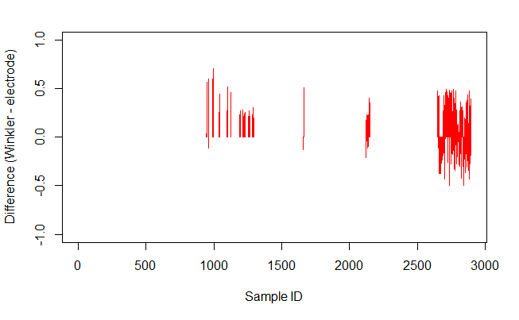

```r
abline(h = eetm, col = 'black', lty = 2)
mtext(side = 3, 'Original data differences (red), corrected data differences (black)')
```

Then differences over dissolved oxygen concentration were analyzed to ensure that there was random scatter around zero rather than increasing trend observed in original data

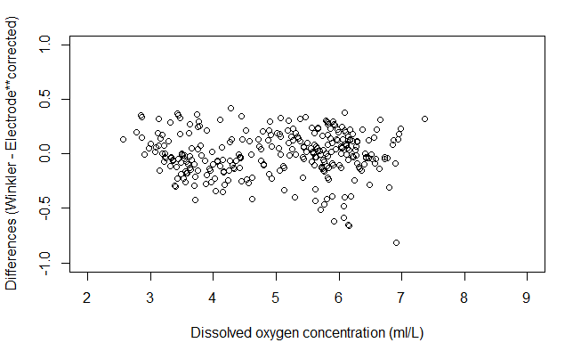

```r
#plot new corrected data over DO concentration
plot(eet, wt_eet, xlim = c(2,9), ylim = c(-1,1), ylab = 'Differences (Winkler - Electrode**corrected)', xlab = "Dissolved oxygen concentration (ml/L)")
```

Gordana suggested plotting differences between WInkler and Electrode measurements over lab - in situ temparture differences to see if the temperature difference had a significant effect on the dissolved oxygen readings.

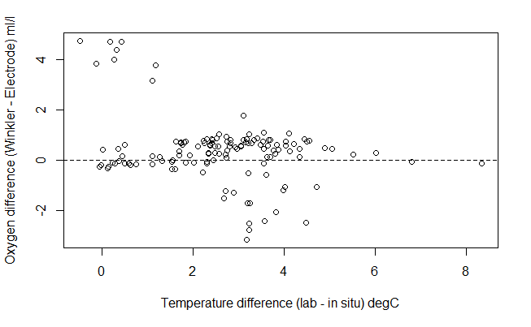

```r
x <- readxl::read_xlsx('C:/Users/ChisholmE/Desktop/BIOCHEM/hud2011004_tdiff_exercise.xlsx')
w_e_diff <- x$`W - E difference`
t_diff <- x$`lab - in situ temp (mean)`
plot(t_diff, w_e_diff, xlab = 'Temperature difference (lab - in situ) degC', ylab = 'Oxygen difference (Winkler - Electrode) ml/l')
abline(h = 0, lty = 2)
```

This plot shows no significant trends in dissolved oxygen concentration over temperature differences.The points are mostly scattered around zero with some outliers at lower temperature differences, as well as some low values between 3 and 5 deg C temperature differences.

Plotting differences in oxygen over lab temperature was inconclusive. Samples are from HUD2011004

```
NAs introduced by coercion
```

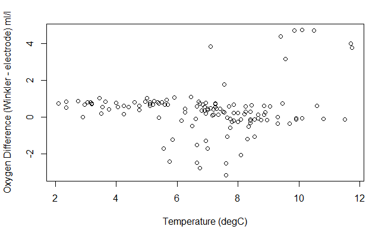

```r
x <- readxl::read_xlsx('C:/Users/ChisholmE/Desktop/BIOCHEM/hud2011004_tdiff_exercise.xlsx' )
w_e_diff <- x$`W - E difference`
plot(x$X__11, w_e_diff, xlab = 'Temperature (degC)', ylab = 'Oxygen Difference (Winkler - electrode) ml/l')
```